# HW3

Cezary Rybak

2022-11-23

# Badanie czytelności wykresów

W ramach zadania przygotowałem 2 wykresy słupkowe oparte na różnych danych (żeby przy udzielaniu odpowiedzi w ankietach nie sugerować się odczuciami z poprzedniego wykresu). Formularz wypełniło na moment pisania raportu 16 osób, znajduje się on pod linkiem: https://forms.gle/G8FcCe3uZvJbzwKR9. Warto zaznaczyć że dane na wykresach są prawdziwe i pobrane z udostępnionych baz danych GUS-u.

## Wykresy

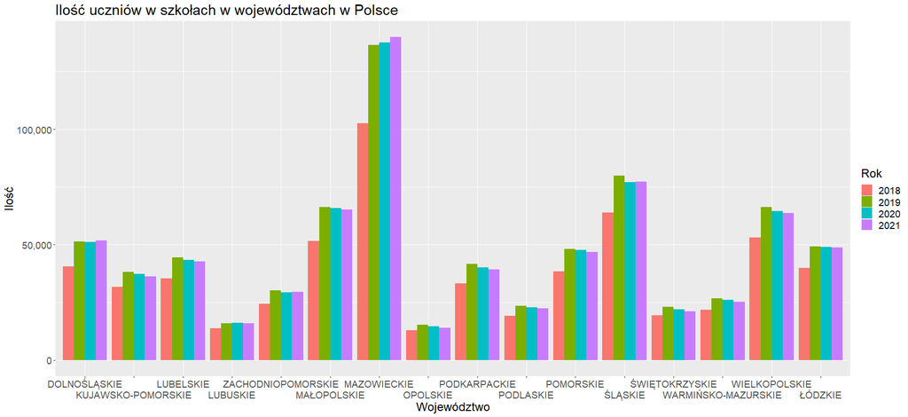

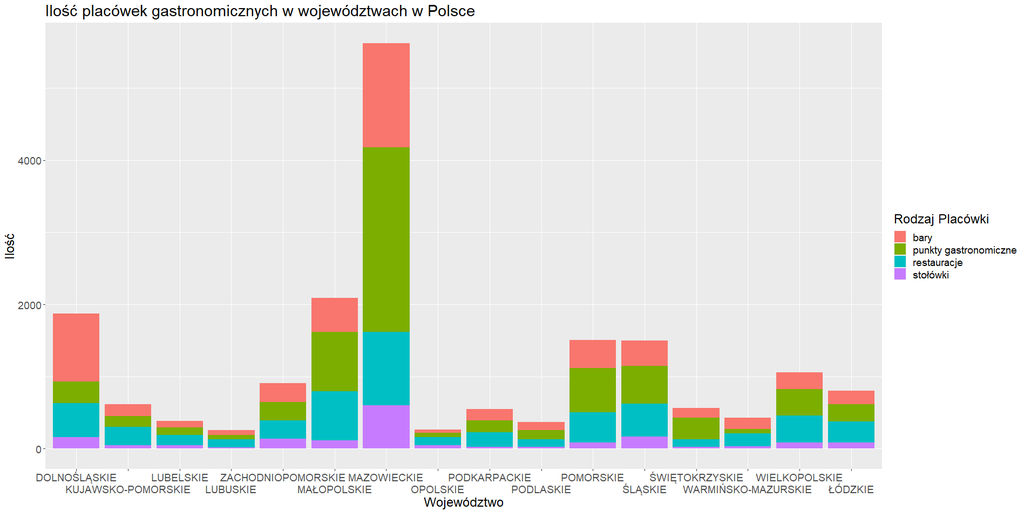

W zasadzie główną różnicą wykresów jest ustawienie słupków, tzn na pierwszym te oddzielone za rok są od siebie oddzielone, a na drugim postawione jeden na drugim i to co ma je odróżniać to kolor, przez co powinniśmy spodziewać się potencjalnie błędnych odczytów z wykresu.

## Pytania do 1 wykresu

### W którym województwie była druga największa liczba uczniów w 2020 roku?

Poprawna odpowiedź to woj. śląskie.  
Odpowiedziało tak aż 75% ankietowanych.  
Za to blisko 20% osób podało mazowieckie, co ewidentnie pokazuje brak poprawnego przeczytania pytania

### W którym roku była największa liczba uczniów w całej Polsce?

Poprawna odpowiedź to 2019.  
Pomimo dość bliskich wyników 2019, 2020 i 2021 roku, 63% osób wskazało poprawnie.  
Ponownie, 13% osób nie przeczytało dokładnie pytania i na pytanie o rok dało odpowiedź “Mazowieckie” ;)

### Ile około było więcej uczniów w woj. mazowieckim w 2019r. względem 2018r.? Odpowiedź może być wartością bezwględną lub względną (procentem)

Dokładne wartości to 34 000 lub 33%.  
Odpowiedzi były dość rozbieżne, co ciekawe w znacznej większości zaniżone, około połowę odpowiedzi uznałbym za bliską.

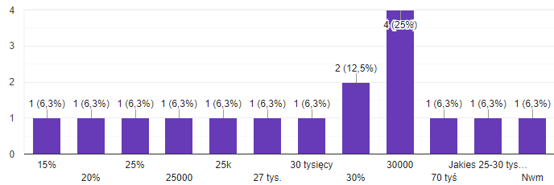

## Pytania do 2 wykresu

### W którym województwie była trzecia największa ilość restauracji?

Poprawna odpowiedź - Dolnośląskie.  
Odpowiedziało tak prawie 70% ankietowanych co uważam za bardzo dobry wynik.  
Reszta odpowiedzi to były pojedyńcze inne województwa, więcej niż raz pojawiało się jeszcze śląskie.

### W ilu województwach jest więcej restauracji niż punktów gastronomicznych?

Takich województw jest łącznie 10.  
Odpowiedzi bardzo rozbieżne, w większości dalekie od poprawnej odpowiedzi.

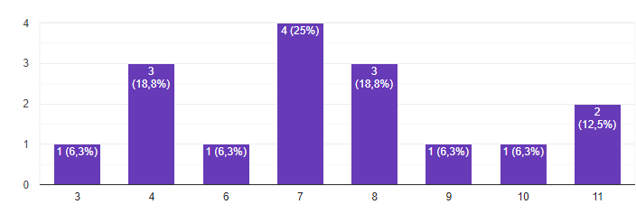

### Około ile barów znajduje się w województwie mazowieckim?

Dokładna odpowiedz - 1449.

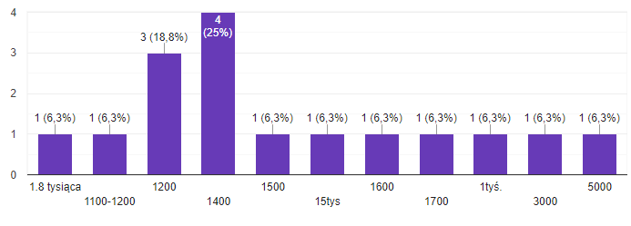

W zasadzie nie mam pojęcia jak interpretować te wyniki, część z nich jest bardzo bliska dokładnego wyniku, jednakże można jako oczywistość uznać, że przy przedstawieniu tych danych na wykresie z oddzielnymi słupkami dla każdego rodzaju placówki wyniki powinny być znacznie lepsze.

# Wnioski

W trakcie procesu tworzenia wykresów i pytań do nich zakładałem, że odpowiedzi do pierwszego wykresu będą znacznie lepsze, niż do drugiego. I faktycznie, są lepsze, jednakże w stosunkowo niedużym stopniu. Oczywiście przez układ nakładania na siebie wykresów w tzw. wieżowiec porównywanie dokładnych wartości jest obarczone większym błędem, jednakże ma to swoje zalety w postaci pokazania danych całościowo, nie zwracając aż tak dużej uwagi na pokolorowane grupy. Dodatkowo okazuje się, że ludzie i tak są w stanie z niedużym błędem ocenić rozłożenie tych grup na słupku.  
Można powiedzieć że z badania nie ma restrykcyjnych wniosków, a raczej, że obydwa sposoby budowy wykresów mają swoje zastosowania, zależne od kontekstu. Za to wyszło, że bez znaczenia czy zrobi się ładny wykres, czy nie, i tak znajdzie się część ludzi, która będzie zbyt leniwa żeby przeczytać opis i i tak przez to wyniesie błędne wnioski.